# Downstream analysis of single-cell RNA-seq read counts

2019-07-10

This workflow is adapted from portions of the [simpleSingleCell Bioconductor workflow](https://www.bioconductor.org/help/workflows/simpleSingleCell/) by Aaron Lun, Davis McCarthy, and John Marioni. Some sections have been simplified, additional material has been added exploring additional methods, and exercises have been added.

# 1 Load data object created in previous vignette

Here we continue our analysis of a relatively simple dataset (Lun et al. 2017) that we began in the previous vignette “Preprocessing and normalization of single-cell RNA-seq read counts”. We’ll load in the `SingleCellExperiment` object we previously saved.

```r
sce <- readRDS(file="416B_postQC.rds")
```

# 2 Denoising expression values using PCA

Once the technical noise is modelled, we can use principal components analysis (PCA) to remove random technical noise. Consider that each cell represents a point in the high-dimensional expression space, where the spread of points represents the total variance. PCA identifies axes in this space that capture as much of this variance as possible. Each axis is a principal component (PC), where any early PC will explain more of the variance than a later PC.

We assume that biological processes involving co-regulated groups of genes will account for the most variance in the data. If this is the case, this process should be represented by one or more of the earlier PCs. In contrast, random technical noise affects each gene independently and will be represented by later PCs. The `denoisePCA()` function removes later PCs until the total discarded variance is equal to the sum of technical components for all genes used in the PCA, using the technical components estimated from `decomposeVar()`. This function will only use genes that have positive biological components, i.e., variances greater than the fitted trend. This guarantees that the total technical variance to be discarded will not be greater than the total variance in the data.

```r
library(scran)
var.fit <- trendVar(sce, parametric=TRUE, block=sce$Plate,
    loess.args=list(span=0.3))
var.out <- decomposeVar(sce, var.fit)
sce <- denoisePCA(sce, technical=var.out, assay.type="corrected")
dim(reducedDim(sce, "PCA"))
```

```
## [1] 183  24
```

The function returns a `SingleCellExperiment` object containing the PC scores for each cell in the `reducedDims` slot. The aim is to eliminate technical noise and enrich for biological signal in the retained PCs. This improves resolution of the underlying biology during downstream procedures such as clustering.

# 3 Visualizing data in low-dimensional space

## 3.1 With PCA

We visualize the relationships between cells by constructing pairwise PCA plots for the first three components (Figure 1). Cells with similar expression profiles should be located close together in the plot, while dissimilar cells should be far apart. In this case, we observe a clear separation of cells based on the oncogene induction status, consistent with the expected effects on the transcriptome.

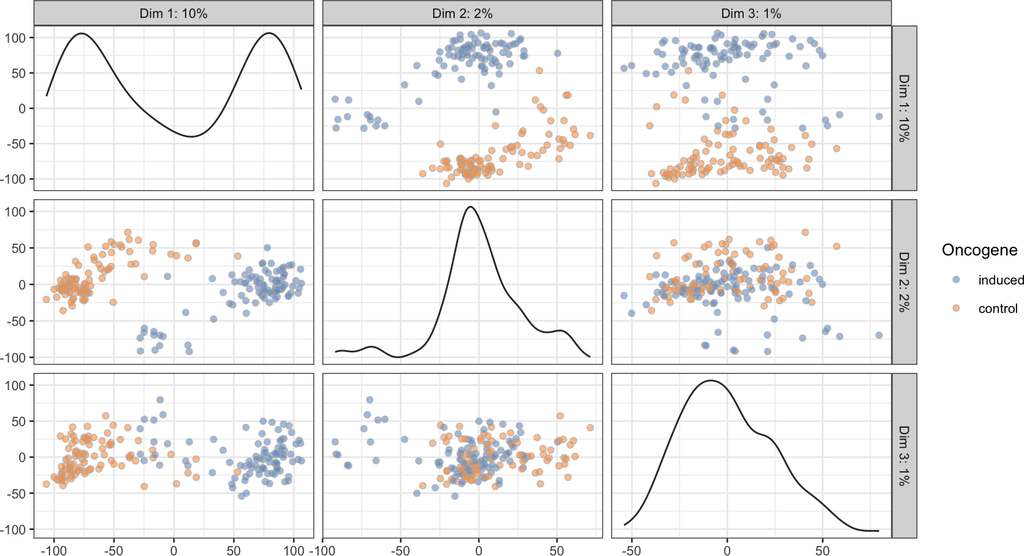

Figure 1: Pairwise PCA plots of the first three PCs in the 416B dataset, constructed from normalized log-expression values of genes with positive biological components  
Each point represents a cell, coloured according to oncogene induction status.

```r
library(scater)
plotReducedDim(sce, use_dimred="PCA", ncomponents=3,
    colour_by="Oncogene")
```

By comparison, we observe no clear separation of cells by batch (Figure 2). This indicates that our batch correction step using `removeBatchEffect()` was successful.

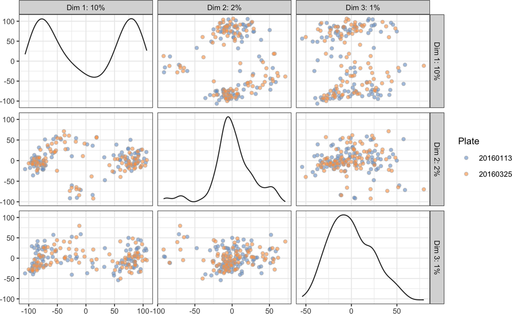

Figure 2: Pairwise PCA plots of the first three PCs in the 416B dataset, constructed from normalized log-expression values of genes with positive biological components  
Each point represents a cell, coloured according to the plate of origin.

```r
plotReducedDim(sce, use_dimred="PCA", ncomponents=3,
    colour_by="Plate")
```

Note that for each visualization method, additional cell-specific information can be incorporated into the size or shape of each point. This is done using the `size_by=` and `shape_by=` arguments in most plotting functions. Also note that `plotReducedDim()` will use the PCA results that were already stored in `sce` by `denoisePCA()`. This allows us to rapidly generate new plots with different aesthetics, without repeating the entire PCA computation. Similarly, `plotPCA()` will use existing results if they are available in the `SingleCellExperiment`, and will recalculate them otherwise. Users should set `rerun=TRUE` to forcibly recalculate the PCs in the presence of existing results.

## 3.2 With *t*-SNE

Another widely used approach for dimensionality reduction is the *t*-stochastic neighbour embedding (*t*-SNE) method (Van der Maaten and Hinton 2008). *t*-SNE tends to work better than PCA for separating cells in more diverse populations. This is because the former can directly capture non-linear relationships in high-dimensional space, whereas the latter must represent them on linear axes. However, this improvement comes at the cost of more computational effort and requires the user to consider parameters such as the random seed and perplexity (see comments).

We demonstrate the generation of *t*-SNE plots in Figure 3 using the `plotTSNE()` function. We set `use_dimred="PCA"` to perform the *t*-SNE on the low-rank approximation of the data, allowing the algorithm to take advantage of the previous denoising step.

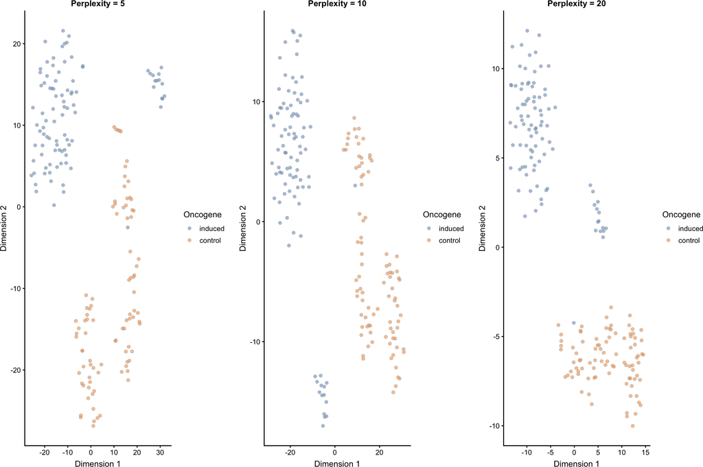

```r
set.seed(100)
out5 <- plotTSNE(sce, run_args=list(use_dimred="PCA", perplexity=5),
    colour_by="Oncogene")  + ggtitle("Perplexity = 5")
set.seed(100)
out10 <- plotTSNE(sce, run_args=list(use_dimred="PCA", perplexity=10),
    colour_by="Oncogene")  + ggtitle("Perplexity = 10")
set.seed(100)
out20 <- plotTSNE(sce, run_args=list(use_dimred="PCA", perplexity=20),
    colour_by="Oncogene")  + ggtitle("Perplexity = 20")
multiplot(out5, out10, out20, cols=3) + theme(text = element_text(size=14))
```

*t*-SNE is a stochastic method, so users should run the algorithm several times to ensure that the results are representative. Scripts should set a seed (via the `set.seed()` command) to ensure that the chosen results are reproducible. It is also advisable to test different settings of the “perplexity” parameter as this will affect the distribution of points in the low-dimensional space.

Here, we call `runTSNE()` with a perplexity of 20 to store the *t*-SNE results inside our `SingleCellExperiment` object. This avoids repeating the calculations whenever we want to create a new plot with `plotTSNE()`, as the stored results will be used instead. Again, users can set `rerun=TRUE` to force recalculation in the presence of stored results.

```r
set.seed(100)
sce <- runTSNE(sce, use_dimred="PCA", perplexity=20)
reducedDimNames(sce)
```

```
## [1] "PCA"  "TSNE"
```

Recall that there are many other dimensionality reduction techniques that we do not consider here but could also be used, e.g., multidimensional scaling, UMAP. A good guide on how to interpret *t*-SNE plots can be found at http://distill.pub/2016/misread-tsne/. This demonstrates how distances between clusters in the 2-dimensional embedding have little meaning, as does the apparent “size” (i.e., spread) of the clusters.

# 4 Clustering cells into putative subpopulations

## 4.1 Defining cell clusters from expression data

The denoised log-expression values are used to cluster cells into putative subpopulations. Specifically, we perform hierarchical clustering on the Euclidean distances between cells, using Ward’s criterion to minimize the total variance within each cluster. This yields a dendrogram that groups together cells with similar expression patterns across the chosen genes.

```r
pcs <- reducedDim(sce, "PCA")
my.dist <- dist(pcs)
my.tree <- hclust(my.dist, method="ward.D2")
```

Clusters are explicitly defined by applying a dynamic tree cut (Langfelder, Zhang, and Horvath 2008) to the dendrogram. This exploits the shape of the branches in the dendrogram to refine the cluster definitions, and is more appropriate than `cutree` for complex dendrograms. Greater control of the empirical clusters can be obtained by manually specifying `cutHeight` in `cutreeDynamic`. We also set `minClusterSize` to a lower value than the default of 20, to avoid spurious aggregation of distant small clusters.

```r
library(dynamicTreeCut)
my.clusters <- unname(cutreeDynamic(my.tree, distM=as.matrix(my.dist),
    minClusterSize=10, verbose=0))
```

We examine the distribution of cells in each cluster with respect to known factors. Each cluster is comprised of cells from both batches, indicating that the clustering is not driven by a batch effect. Differences in the composition of each cluster are observed with respect to `Oncogene`, consistent with a biological effect of oncogene induction.

```r
table(my.clusters, sce$Plate)
```

```
##
## my.clusters 20160113 20160325
##           1       41       39
##           2       19       20
##           3       16       11
##           4       10       14
##           5        5        8
```

```r
table(my.clusters, sce$Oncogene)
```

```
##
## my.clusters induced control
##           1      80       0
##           2       0      39
##           3       0      27
##           4       0      24
##           5      13       0
```

We visualize the cluster assignments for all cells on the *t*-SNE plot in Figure 4. Adjacent cells are generally assigned to the same cluster, indicating that the clustering procedure was applied correctly.

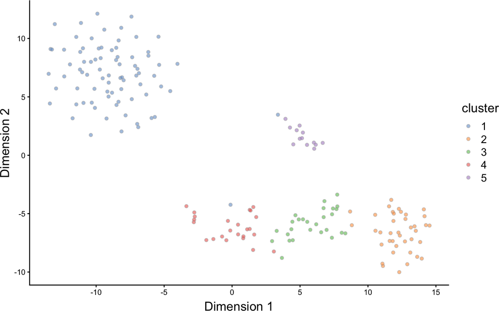

Figure 4: *t*-SNE plot of the denoised PCs of the 416B dataset  
Each point represents a cell and is coloured according to the cluster identity to which it was assigned.

```r
sce$cluster <- factor(my.clusters)
plotTSNE(sce, colour_by="cluster") + theme(text = element_text(size=14))
```

We check the separatedness of the clusters using the silhouette width (Figure 5). Cells with large positive silhouette widths are closer to other cells in the *same* cluster than to cells in *different* clusters. Conversely, cells with negative widths are closer to other clusters than to other cells in the cluster to which it was assigned. Each cluster would ideally contain many cells with large positive widths, indicating that it is well-separated from other clusters.

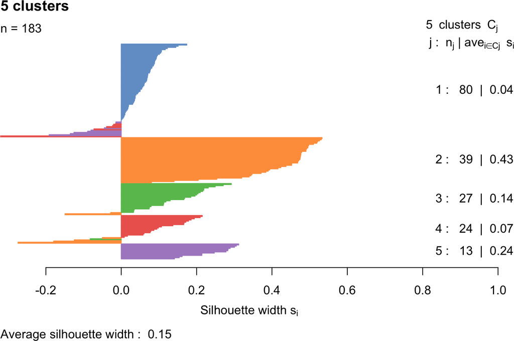

Figure 5: Barplot of silhouette widths for cells in each cluster  
Each cluster is assigned a colour and cells with positive widths are coloured according to the colour of its assigned cluster. Any cell with a negative width is coloured according to the colour of the cluster that it is closest to. The average width for all cells in each cluster is shown, along with the average width for all cells in the dataset.

```r
library(cluster)
clust.col <- scater:::.get_palette("tableau10medium") # hidden scater colours
sil <- silhouette(my.clusters, dist = my.dist)
sil.cols <- clust.col[ifelse(sil[,3] > 0, sil[,1], sil[,2])]
sil.cols <- sil.cols[order(-sil[,1], sil[,3])]
plot(sil, main = paste(length(unique(my.clusters)), "clusters"),
    border=sil.cols, col=sil.cols, do.col.sort=FALSE)
```

The silhouette width can be used to determine the parameter values that maximize the separation between clusters. For example, we could vary the cut height or splitting depth in `cutreeDynamic` to maximize the average silhouette width across all cells. This usually provides a satisfactory initial clustering for further examination. However, keep in mind that the granularity of clustering is much like the magnification on a microscope. Different views of the data can be obtained with different granularities, some of which may be suboptimal on measures of separation. Users should not fixate on the clustering with the greatest separation if it does not provide the desired granularity for a particular biological question.

Most cells have relatively small silhouette positive widths in Figure 5, indicating that the separation between clusters is weak. This may be symptomatic of over-clustering where clusters that are clearly defined on oncogene induction status are further split into subsets that are less well separated. Nonetheless, we will proceed with the current clustering scheme in `my.clusters`, as it provides reasonable partitions for further characterization of heterogeneity.

An alternative clustering strategy is to use a matrix of distances derived from correlations (e.g., as in `quickCluster`). This is more robust to noise and normalization errors, but is also less sensitive to subtle changes in the expression profiles. Both Ward’s criterion and complete linkage yield spherical, compact clusters. In particular, complete linkage favours the formation of clusters with the same diameter. This may be desirable in some cases but is less appropriate when subpopulations differ in their variance. Thus, we typically use Ward’s criterion for our initial clustering. Of course, it is simple (and recommended) to try other approaches provided that some assessment is performed, e.g., using the silhouette width.

## 4.2 Detecting marker genes between clusters

Once putative subpopulations are identified by clustering, we can identify marker genes for each cluster using the `findMarkers` function. This performs Welch $t$-tests on the log-expression values for every gene and between every pair of clusters (Soneson and Robinson 2018). The aim is to test for DE in each cluster compared to the others while blocking on uninteresting factors such as the plate of origin. The top DE genes are likely to be good candidate markers as they can effectively distinguish between cells in different clusters. Optionally, by setting `direction="up"`, `findMarkers` will only return genes that are upregulated in each cluster compared to the others.

```r
markers <- findMarkers(sce, my.clusters, block=sce$Plate)
```

For each cluster, the DE results of the relevant comparisons are consolidated into a single output table. This allows a set of marker genes to be easily defined by taking the top DE genes from each pairwise comparison between clusters. For example, to construct a marker set for cluster 1 from the top 10 genes of each comparison, one would filter `marker.set` to retain rows with `Top` less than or equal to 10. Other statistics are also reported for each gene, including the adjusted $p$-values (see below) and the log-fold changes relative to every other cluster.

```r
marker.set <- markers[["1"]]
head(marker.set, 10)
```

```
## DataFrame with 10 rows and 7 columns
##              Top              p.value                  FDR           logFC.2
##        <integer>            <numeric>            <numeric>         <numeric>
## Aurkb          1 6.65863261824492e-75 1.58362259559721e-70 -7.37163350569914
## Tk1            1 6.41442387689833e-64 3.81385607660686e-60 -4.92754579848056
## Myh11          1 4.95086465211539e-49 9.81220116843835e-46  4.42159318376489
## Cdca8          1 2.22334940769686e-46  3.5251945975503e-43 -6.84273526334783
## Ccna2          2 1.16841222330534e-68 1.38941739534356e-64  -7.3079756458424
## Rrm2           2 1.48873842020081e-56 5.05809512109088e-53 -5.52120322191947
## Cks1b          2 3.83636139889977e-39 2.40105745131667e-36  -6.6792118199827
## Pirb           2 1.83893803490065e-34 6.15992440620318e-32  5.25803749166673
## Pimreg         3 7.41004737119548e-68 5.87443855430467e-64 -7.30454210816126
## Pclaf          3  8.9651722100101e-51 2.13218690670669e-47 -5.60087985621813
##                  logFC.3            logFC.4            logFC.5
##                <numeric>          <numeric>          <numeric>
## Aurkb  -6.72799345321135  -1.95039440976238  -6.91128802096519
## Tk1    -7.74065113926215  -3.53749565362853  -4.63516273649457
## Myh11   4.30812918035861   4.45235717737968    1.0413149433198
## Cdca8  -4.88595092732349  -2.43821402084038  -7.12791471326961
## Ccna2   -6.9676852052539  -2.46589325823089  -7.12692721843331
## Rrm2   -7.94685699818751  -3.19173143688883  -5.42878091964762
## Cks1b  -5.92137181826573  -4.37146346518812    -6.214592473138
## Pirb    5.18195596569259   5.87631057587633 0.0704964218555272
## Pimreg -5.91099762335684 -0.874660676141792  -7.01798853404623
## Pclaf  -7.56997893312346  -2.36631043435985  -5.16956927698937
```

We save the list of candidate marker genes for further examination.

```r
write.table(marker.set, file="416B_marker_1.tsv", sep="\t",
    quote=FALSE, col.names=NA)
```

We visualize the expression profiles of the top candidates to verify that the DE signature is robust (Figure 6). Most of the top markers have strong and consistent up- or downregulation in cells of cluster 1 compared to some or all of the other clusters. A cursory examination of the heatmap indicates that cluster 1 contains oncogene-induced cells with strong downregulation of DNA replication and cell cycle genes. This is consistent with the potential induction of senescence as an anti-tumorigenic response (Wajapeyee et al. 2010). A more comprehensive investigation of the function of these markers can be performed with gene set enrichment analyses, e.g., using `kegga` or `goana` from *limma*.

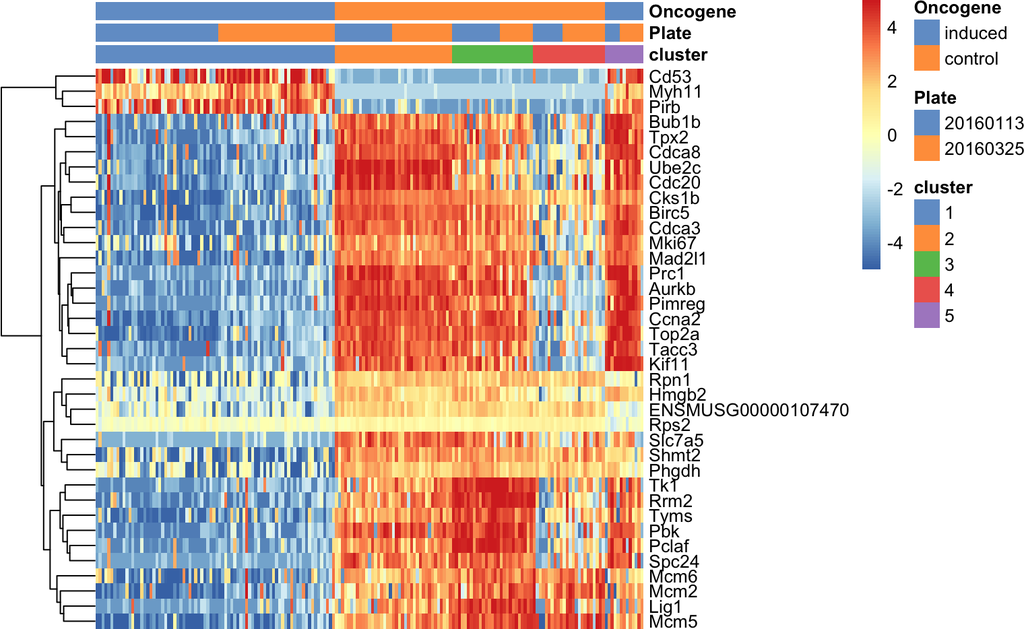

Figure 6: Heatmap of mean-centred and normalized log-expression values for the top set of markers for cluster 1 in the 416B dataset  
Column colours represent the cluster to which each cell is assigned, the plate of origin or the oncogene induction status of each cell, as indicated by the legend.

```r
top.markers <- rownames(marker.set)[marker.set$Top <= 10]
plotHeatmap(sce, features=top.markers, columns=order(sce$cluster),
    colour_columns_by=c("cluster", "Plate", "Oncogene"),
    cluster_cols=FALSE, center=TRUE, symmetric=TRUE, zlim=c(-5, 5),
    show_colnames = FALSE)
```

Many of the markers in Figure 6 are not uniquely up- or downregulated in the chosen cluster. Testing for unique DE tends to be too stringent as it overlooks important genes that are expressed in two or more clusters. For example, in a mixed population of CD4<sup>+</sup>-only, CD8<sup>+</sup>-only, double-positive and double-negative T cells, neither *Cd4* or *Cd8* would be detected as subpopulation-specific markers because each gene is expressed in two subpopulations. With our approach, both of these genes will be picked up as candidate markers as they will be DE between at least one pair of subpopulations. A combination of markers can then be chosen to characterize a subpopulation, which is more flexible than trying to find uniquely DE genes.

We strongly recommend selecting some markers for use in validation studies with an independent replicate population of cells. The aim is to identify a corresponding subset of cells that express the upregulated markers and do not express the downregulated markers.

# 5 Differential expression

Here will identify differentially expressed genes between induced and control cells. Specifically, we’ll identify *differentially distributed* genes using the *scDD* package (Korthauer et al. 2016). This method expects normalized counts (not log-scale) in the `normcounts` slot. Since we also want to adjust for plate effects, we’ll add the `corrected` counts back-transformed to the original scale. However, note that using these corrected values transforms zero values to nonzeroes. So we also enforce that counts that were originally zero remain zero.

```r
assays(sce)$normcounts <- 2^assays(sce)$corrected
assays(sce)$normcounts[counts(sce)==0] <- 0
```

Next we run the `scDD()` function. Note that the function will by default use multiple cores, so we should specify the type of parallelization and number of cores using the *BiocParallel* package. Here we specify use of 1 core with the `MulticoreParam()` function.

For the sake of computational efficiency, here we won’t carry out the classification step (to identify the differential distribution pattern). To do so, you can set `categorize = TRUE`.

```r
library(scDD)
library(BiocParallel)

dd <- scDD(sce, param = MulticoreParam(1), condition = "Oncogene",
           categorize = FALSE)
```

Next we’ll explore the results. First, looking at how many significant genes at FDR 0.01.

```r
sig <- which(results(dd)$combined.pvalue.adj < 0.01)
length(sig)
```

```
## [1] 3552
```

Next, we’ll look at the classification of the top 100 genes. Note that we don’t typically need to do this step separately since this can be done in one step on all the data - just for the sake of efficiency, we only carry out this step on the top 100.

```r
top100 <- which(rank(results(dd)$combined.pvalue.adj,
                     ties = "random") <= 100)

# classification of top 100 genes
class100 <- results(scDD(sce[top100,], param = MulticoreParam(1),
             condition = "Oncogene",
             categorize = TRUE))$DDcategory
```

Next, we plot a set of top genes.

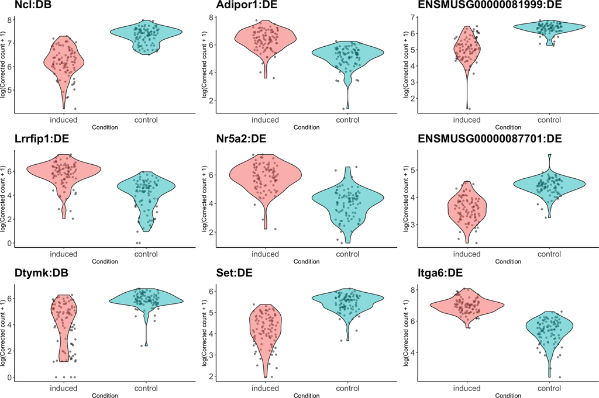

```r
rows <- 3
cols <- 3
par(mfrow=c(rows,cols))
p <- vector("list", rows*cols)
for (g in 1:length(p)){
  p[[g]] <- sideViolin(normcounts(sce)[top100[g],],
             sce$Oncogene,
             title.gene=paste0(rownames(sce)[top100[g]],
             ":", class100[g])) +
    ylab("log(Corrected count + 1)")
}
multiplot(p[[1]], p[[2]], p[[3]], p[[4]],
          p[[5]], p[[6]], p[[7]], p[[8]], p[[9]], cols=cols)
```

# 6 Save object for later use

Once the basic analysis is completed, it is often useful to save the `SingleCellExperiment` object to file with the `saveRDS` function. The object can then be easily restored into new R sessions using the `readRDS` function. This allows further work to be conducted without having to repeat all of the processing steps described above.

```r
saveRDS(file="416B_data.rds", sce)
```

# 7 Exercises

## 7.1 PCA on uncorrected data

Recreate the PCA plots for the first three dimensions, colored by plate, but this time using the uncorrected log counts in the `logcounts` assays slot (instead of the `corrected` counts that were adjusted for batch in the previous Rmd). Which PC contains the most variation in plate?

```r
sce <- denoisePCA(sce, technical=var.out, assay.type="logcounts")
dim(reducedDim(sce, "PCA"))
```

```
## [1] 183  24
```

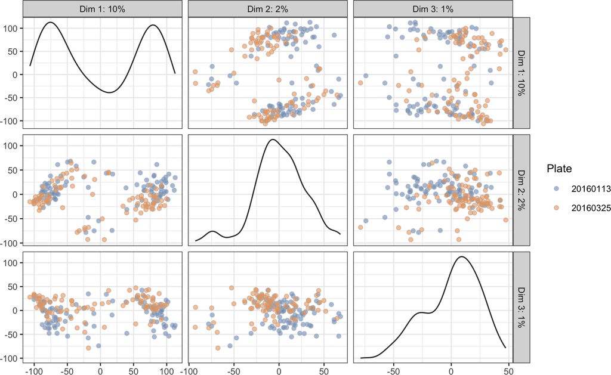

```r
plotReducedDim(sce, use_dimred="PCA", ncomponents=3,
    colour_by="Plate")
```

## 7.2 tSNE on noise

Let’s see what happens when we perform tSNE on random noise. Use the following matrix of 1000 features on 100 samples:

```r
set.seed(30)
y <- matrix(rnorm(100000), ncol=100)
```

Perform tSNE dimensional reduction and plot the first two components. See how much structure you can impose by varying the parameters of the algorithm. Hint: you can use the `Rtsne` package, and try varying the `perplexity` and/or other paramters.

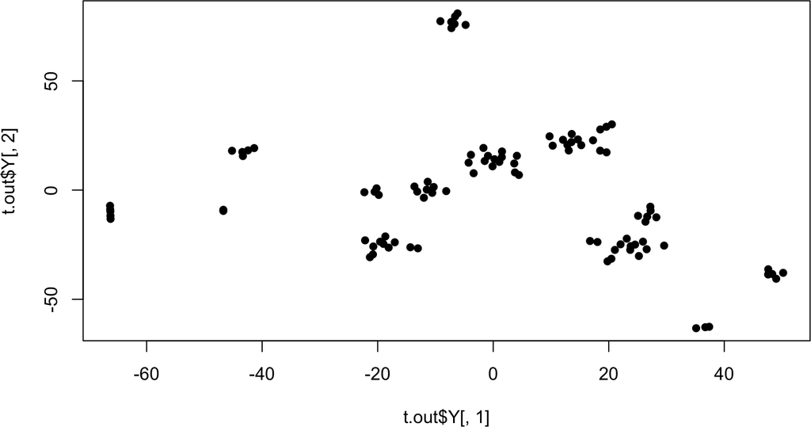

```r
library(Rtsne)
set.seed(1)
t.out <- Rtsne(t(y), perplexity = 1)
plot(t.out$Y[,1], t.out$Y[,2], pch=16)
```

## 7.3 Comparison with MAST DE results (Advanced)

Use the method *MAST* to call differentially expressed genes between induced and control cells. Since `MAST` is not fully compatible with `SingleCellExperiment` assays and expects log normalized counts, you’ll need to use this `sca` object which is a `SingleCellAssay` constructed from the `SingleCellExperiment`.

```r
library(MAST)
sca <- FromMatrix(assays(sce)$logcounts, colData(sce), rowData(sce))
```

```r
zlmCond <- zlm(~Oncogene, sca)
lrt <- lrTest(zlmCond, "Oncogene")
sum(p.adjust(lrt[,3,3]) < 0.01)
```

```
## [1] 2188
```

```r
table(p.adjust(lrt[,3,3]) < 0.01, results(dd)$combined.pvalue.adj < 0.01)
```

```
##
##         FALSE  TRUE
##   FALSE 19865  1810
##   TRUE    446  1742
```

# References

Korthauer, Keegan D, Li-Fang Chu, Michael A Newton, Yuan Li, James Thomson, Ron Stewart, and Christina Kendziorski. 2016. “A Statistical Approach for Identifying Differential Distributions in Single-Cell Rna-Seq Experiments.” *Genome Biology* 17 (1). BioMed Central: 222.

Langfelder, P., B. Zhang, and S. Horvath. 2008. “Defining clusters from a hierarchical cluster tree: the Dynamic Tree Cut package for R.” *Bioinformatics* 24 (5): 719–20.

Lun, A. T. L., F. J. Calero-Nieto, L. Haim-Vilmovsky, B. Gottgens, and J. C. Marioni. 2017. “Assessing the reliability of spike-in normalization for analyses of single-cell RNA sequencing data.” *Genome Res.* 27 (11): 1795–1806.

Soneson, C., and M. D. Robinson. 2018. “Bias, robustness and scalability in single-cell differential expression analysis.” *Nat. Methods* 15 (4): 255–61.

Van der Maaten, L., and G. Hinton. 2008. “Visualizing Data Using T-SNE.” *J. Mach. Learn. Res.* 9 (2579-2605): 85.

Wajapeyee, N., S. Z. Wang, R. W. Serra, P. D. Solomon, A. Nagarajan, X. Zhu, and M. R. Green. 2010. “Senescence induction in human fibroblasts and hematopoietic progenitors by leukemogenic fusion proteins.” *Blood* 115 (24): 5057–60.